# Day 4: Exploratory data analysis

## Do this before class

Read [R4DS](http://r4ds.had.co.nz/) chapter 7.

Solve *Exploring Categorical Data* and *Exploring Numerical Data* at [DataCamp](https://www.datacamp.com/enterprise/mt5013-ht18/assignments).

## During class

### Systembolaget’s assortment

- Use `filter` to extract the groups of products `c("Vitt vin", "Rött vin", "Rosévin", "Mousserande vin")` of vintage 2011-2018. Try and compare the following bar charts
  - `ggplot` with `aes(x = Argang)`, `geom_bar()` and
  - `ggplot` with `aes(x = Argang)`, `geom_bar()` and `facet_wrap(~ Varugrupp)` (try adding `scale = "free_y"` to `facet_wrap`)
  - `ggplot` with `aes(x = Argang, fill = Varugrupp)` and
    - `geom_bar()`
    - `geom_bar(position = "dodge")`
    - `geom_bar(position = "fill")`
- Recreate the following plot (Red wines in the regular range)

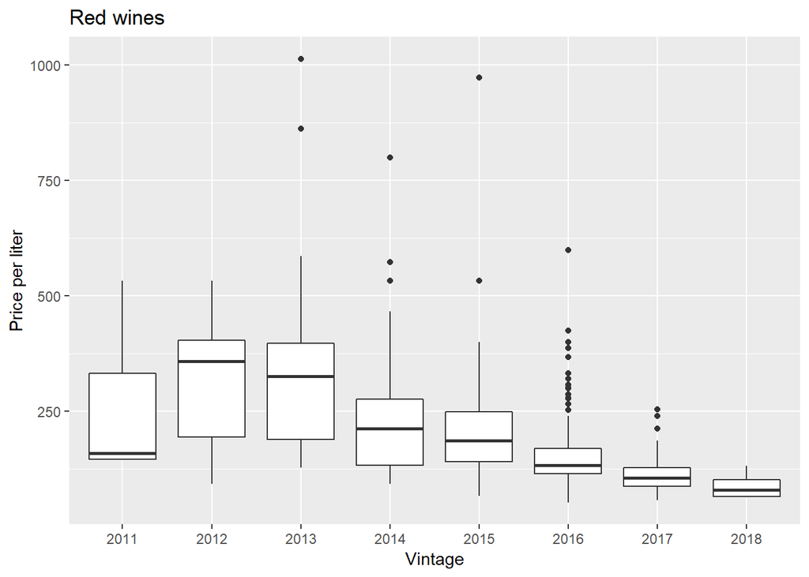

- Make a `box_plot` of `PrisPerLiter` on the log-scale,with `x = Varugrupp`. Try `coord_flip` to improve readability.

### Winter medals

The following code transforms the medals data to “long” format (more about this next time!) which is easier to work with in `ggplot`:

```r
medal_long <- read_csv("Class_files/Winter_medals2018-09-26.csv") %>%
    select(-Total) %>%
    gather(Denomination, Number, c("Gold", "Silver", "Bronze"))
```

Check the result with `glimpse(medal_long)`. Use `group_by` and `summarise` in order to aggregate the total number of medals of each denomination (Gold/Silver/Bronze) for each country. Illustrate the relative proportions of denominations, e.g. by `geom_bar` with `stat = "identity` and `position = "fill"`.